# Big Data Statistics for R and Python

25/02/2019

## Updates

## Build groups for group examination

- Teams of 2-3.
- Forum on StudyNet.
- All team members must have a GitHub account.

## Group examination

- Analysis of (big) dataset in R.
- Report on analysis in R Markdown.
- Conceptual questions.
- Collaborate, hand-in, feedback via GitHub.

## Recap of Week 1

## Class Survey: Big Data?

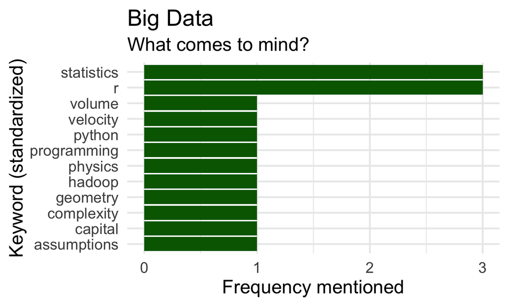

## Schedule: Part I

1. Introduction: Big Data, Data Economy (Concepts). M: Walkowiak (2016): Chapter 1
2. *Programming with Data, R Refresher Course (Concepts/Applied). M: Walkowiak (2016): Chapter 2*
3. Computation and Memory (Concepts)
4. Cleaning and Transformation of Big Data (Applied). M: Walkowiak (2016): Chapter 3: p. 74‐118.
5. Aggregation and Visualization (Applied: data tables, ggplot). M: Walkowiak (2016): Chapter 3: p. 118‐127. C: Wickham et al. (2015), Schwabish (2014).
6. Distributed Systems, MapReduce/Hadoop with R (Concepts/Applied). M: Walkowiak (2016): Chapter 4
7. Data Storage, Databases Interaction with R. M: Walkowiak (2016): Chapter 5

## Notes, Slides, Code, et al.

- [umatter.github.io/courses](https://umatter.github.io/courses.html)
- github.com/umatter/BigData
- [StudyNet](https://fronter.com/unisg/main.phtml)

## Suggested Learning Procedure

- Clone/fork the course's GitHub-repository.
- During class, use the Rmd-file of the slide-set as basis for your notes.
- After class, enrich/merge/extend your notes with the lecture notes.

## Goals for Today

1. Get familiar with the tools.
2. Get overview over key aspects of programming with big data in R.
3. First hands-on experience with big data statistics.

## The Tools: R, RStudio, GitHub, etc.


## Data Projects with GitHub

[figure not shown]

Image by [jonobacon](https://www.flickr.com/photos/jonobacon/22160892602) ([CC BY 2.0](https://creativecommons.org/licenses/by/2.0/))

## Version control with Git

- Keep track of your code.
- Develop in different branches.
- Safely go back to previous versions.

## Code repository on GitHub

- Work from different machines.
- Manage and document the project.
- Publish and collaborate.

## Data Structures and Data Types

## R-tools to investigate structures and types

| package | function | purpose |
| --- | --- | --- |
| `utils` | `str()` | Compactly display the structure of an arbitrary R object. |
| `base` | `class()` | Prints the class(es) of an R object. |
| `base` | `typeof()` | Determines the (R-internal) type or storage mode of an object. |

## Structures to work with (in R)

We distinguish two basic characteristics:

1. Data **types**: integers; real numbers ('numeric values', floating point numbers); text ('string', 'character values').

## Structures to work with (in R)

We distinguish two basic characteristics:

1. Data **types**: integers; real numbers ('numeric values', floating point numbers); text ('string', 'character values').
2. Basic **data structures** in RAM:
   - *Vectors*
   - *Factors*
   - *Arrays/Matrices*
   - *Lists*
   - *Data frames* (very `R`-specific)

## Data types: numeric

```r
a <- 1.5
b <- 3
```

R interprets this data as type `double` (class 'numeric'):

```r
typeof(a)
```

```
## [1] "double"
```

```r
class(a)
```

```
## [1] "numeric"
```

## Data types: numeric

Given that these bytes of data are interpreted as numeric, we can use operators (here: math operators) that can work with such functions:

```r
a + b
```

```
## [1] 4.5
```

## Data types: character

```r
a <- "1.5"
b <- "3"
```

```r
typeof(a)
```

```
## [1] "character"
```

```r
class(a)
```

```
## [1] "character"
```

## Data types: character

Now the same line of code as above will result in an error:

```r
a + b
```

```
## Error in a + b: non-numeric argument to binary operator
```

## Data structures: Vectors

Example:

```r
persons <- c("Andy", "Brian", "Claire")
persons
```

```
## [1] "Andy"   "Brian"  "Claire"
```

```r
ages <- c(24, 50, 30)
ages
```

```
## [1] 24 50 30
```

## Data structures: Factors

Example:

```r
gender <- factor(c("Male", "Male", "Female"))
gender
```

```
## [1] Male   Male   Female
## Levels: Female Male
```

## Data structures: Matrices/Arrays

Example:

```r
my_matrix <- matrix(c(1,2,3,4,5,6), nrow = 3)
my_matrix
```

```
##      [,1] [,2]
## [1,]    1    4
## [2,]    2    5
## [3,]    3    6
```

```r
my_array <- array(c(1,2,3,4,5,6), dim = 3)
my_array
```

```
## [1] 1 2 3
```

## Data frames, tibbles, and data tables

Example:

```r
df <- data.frame(person = persons, age = ages, gender = gender)
df
```

```
##   person age gender
## 1   Andy  24   Male
## 2  Brian  50   Male
## 3 Claire  30 Female
```

## Data structures: Lists

Example:

```r
my_list <- list(my_array, my_matrix, df)
my_list
```

```
## [[1]]
## [1] 1 2 3
##
## [[2]]
##      [,1] [,2]
## [1,]    1    4
## [2,]    2    5
## [3,]    3    6
##
## [[3]]
##   person age gender
## 1   Andy  24   Male
## 2  Brian  50   Male
## 3 Claire  30 Female
```

## Programming with (Big) Data in R

## Typical Programming Tasks

- Procedures to import/export data.
- Procedures to clean and filter data.
- Implement functions for statistical analysis.

## Programming with Big Data

1. Which basic (already implemented) R functions are more or less suitable as building blocks for the program?
2. How can we exploit/avoid some of R's lower-level characteristics in order to implement efficient functions?
3. Is there a need to interface with a lower-level programming language in order to speed up the code? (advanced topic)
- Independent of *how* we write a statistical procedure in R (or in any other language, for that matter), is there an *alternative statistical procedure/algorithm* that is faster but delivers approximately the same result.

## Building blocks for programming with big data

- Several basic functions and packages that provide similar function. Which one to use?
- Example: Data import.
  - `utils::read.csv()`
  - `data.table::fread()`

## Building blocks for programming with big data

```r
# read a CSV-file the 'traditional way'
flights <- read.csv("../data/flights.csv")
class(flights)
```

```
## [1] "data.frame"
```

```r
# alternative (needs the data.table package)
library(data.table)
flights <- fread("../data/flights.csv")
class(flights)
```

```
## [1] "data.table" "data.frame"
```

## Building blocks for programming with big data

```r
system.time(flights <- read.csv("../data/flights.csv"))
```

```
##    user  system elapsed
##   2.695   0.191   2.868
```

```r
system.time(flights <- fread("../data/flights.csv"))
```

```
##    user  system elapsed
##   0.362   0.045   0.167
```

## Writing efficient code

- Memory allocation (before looping)
- Vectorization (different approaches)
- Beyond R

## Memory allocation before looping

```r
# naïve implementation
sqrt_vector <-
     function(x) {
          output <- c()
          for (i in 1:length(x)) {
               output <- c(output, x[i]^(1/2))
          }

          return(output)
     }
```

## Memory allocation before looping

```r
# implementation with pre-allocation of memory
sqrt_vector_faster <-
     function(x) {
          output <- rep(NA, length(x))
          for (i in 1:length(x)) {
               output[i] <-  x[i]^(1/2)
          }

          return(output)
     }
```

## Memory allocation before looping

*Test it!*

```r
# the different sizes of the vectors we will put into the two functions
input_sizes <- seq(from = 100, to = 10000, by = 100)
# create the input vectors
inputs <- sapply(input_sizes, rnorm)

# compute ouputs for each of the functions
output_slower <-
     sapply(inputs,
            function(x){ system.time(sqrt_vector(x))["elapsed"]
                 }
            )
output_faster <-
     sapply(inputs,
            function(x){ system.time(sqrt_vector_faster(x))["elapsed"]
                 }
            )
```

## Memory allocation before looping

*Test it!*

```r
# load packages
library(ggplot2)

# initiate data frame for plot
plotdata <- data.frame(time_elapsed = c(output_slower, output_faster),
                       input_size = c(input_sizes, input_sizes),
                       Implementation= c(rep("sqrt_vector", length(output_slower)),
                            rep("sqrt_vector_faster", length(output_faster))))
```

## Memory allocation before looping

*Test it!*

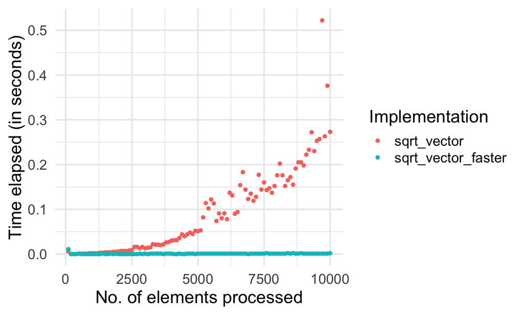

```r
# plot
ggplot(plotdata, aes(x=input_size, y= time_elapsed)) +
     geom_point(aes(colour=Implementation)) +
     theme_minimal(base_size = 18) +
     ylab("Time elapsed (in seconds)") +
     xlab("No. of elements processed")
```

## Vectorization

- "In R, everything is a vector…"
- Directly operate on vectors, not elements.
- Avoid unnecessary repetition of 'preparatory steps'.

## Vectorization: Example

```r
# implementation with vectorization
sqrt_vector_fastest <-
     function(x) {
               output <-  x^(1/2)
          return(output)
     }

# speed test
output_fastest <-
     sapply(inputs,
            function(x){ system.time(sqrt_vector_fastest(x))["elapsed"]
                 }
            )
```

## Vectorization: Example

*Test it!*

```r
# load packages
library(ggplot2)

# initiate data frame for plot
plotdata <- data.frame(time_elapsed = c(output_faster, output_fastest),
                       input_size = c(input_sizes, input_sizes),
                       Implementation= c(rep("sqrt_vector_faster", length(output_faster)),
                            rep("sqrt_vector_fastest", length(output_fastest))))
```

## Vectorization: Example

*Test it!*

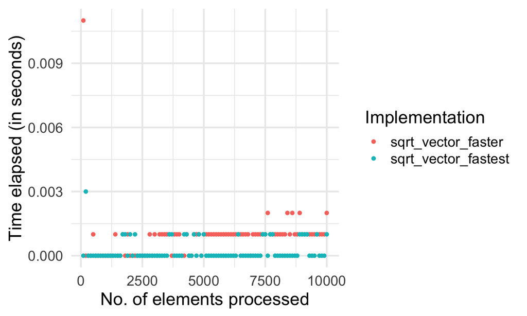

```r
# plot
ggplot(plotdata, aes(x=input_size, y= time_elapsed)) +
     geom_point(aes(colour=Implementation)) +
     theme_minimal(base_size = 18) +
     ylab("Time elapsed (in seconds)") +
     xlab("No. of elements processed")
```

## Vectorization: `apply`-type functions vs loops

- Apply a function to each element of a vector/list.
- For example, `lapply()`.

## Example

- Read several data files into R.
- Example data source: [Health News in Twitter Data Set](https://archive.ics.uci.edu/ml/datasets/Health+News+in+Twitter) by Karami et al. (2017).
- Loop vs `lapply()`, vs `Vectorization()`

## Example: Preparations

```r
# load packages
library(data.table)

# get a list of all file-paths
textfiles <- list.files("../data/twitter_texts", full.names = TRUE)
```

## Example: `for`-loop approach

```r
# prepare loop
all_texts <- list()
n_files <- length(textfiles)
length(all_texts) <- n_files
# read all files listed in textfiles
for (i in 1:n_files) {
     all_texts[[i]] <- fread(textfiles[i])
}
```

## Example: `for`-loop approach

*Check the results*

```r
# combine all in one data.table
twitter_text <- rbindlist(all_texts)
# check result
str(twitter_text)
```

```
## Classes 'data.table' and 'data.frame':   42422 obs. of  3 variables:
##  $ V1:integer64 585978391360221184 585947808772960257 585947807816650752 585866060991078401 585794106170839041 585733482413891584 585733481608646657 585701601131765761 ...
##  $ V2: chr  "Thu Apr 09 01:31:50 +0000 2015" "Wed Apr 08 23:30:18 +0000 2015" "Wed Apr 08 23:30:18 +0000 2015" "Wed Apr 08 18:05:28 +0000 2015" ...
##  $ V3: chr  "Breast cancer risk test devised http://bbc.in/1CimpJF" "GP workload harming care - BMA poll http://bbc.in/1ChTBRv" "Short people's 'heart risk greater' http://bbc.in/1ChTANp" "New approach against HIV 'promising' http://bbc.in/1E6jAjt" ...
##  - attr(*, ".internal.selfref")=<externalptr>
```

## Example: `lapply` approach

```r
# prepare loop
all_texts <- lapply(textfiles, fread)
# combine all in one data.table
twitter_text <- rbindlist(all_texts)
# check result
str(twitter_text)
```

```
## Classes 'data.table' and 'data.frame':   42422 obs. of  3 variables:
##  $ V1:integer64 585978391360221184 585947808772960257 585947807816650752 585866060991078401 585794106170839041 585733482413891584 585733481608646657 585701601131765761 ...
##  $ V2: chr  "Thu Apr 09 01:31:50 +0000 2015" "Wed Apr 08 23:30:18 +0000 2015" "Wed Apr 08 23:30:18 +0000 2015" "Wed Apr 08 18:05:28 +0000 2015" ...
##  $ V3: chr  "Breast cancer risk test devised http://bbc.in/1CimpJF" "GP workload harming care - BMA poll http://bbc.in/1ChTBRv" "Short people's 'heart risk greater' http://bbc.in/1ChTANp" "New approach against HIV 'promising' http://bbc.in/1E6jAjt" ...
##  - attr(*, ".internal.selfref")=<externalptr>
```

## Example: `Vectorization` approach

```r
# initiate the import function
import_file <-
     function(x) {
          parsed_x <- fread(x)
          return(parsed_x)
     }

# 'vectorize' it
import_files <- Vectorize(import_file, SIMPLIFY = FALSE)
```

## Example: `Vectorization` approach

```r
# Apply the vectorized function
all_texts <- import_files(textfiles)
twitter_text <- rbindlist(all_texts)
# check the result
str(twitter_text)
```

```
## Classes 'data.table' and 'data.frame':   42422 obs. of  3 variables:
##  $ V1:integer64 585978391360221184 585947808772960257 585947807816650752 585866060991078401 585794106170839041 585733482413891584 585733481608646657 585701601131765761 ...
##  $ V2: chr  "Thu Apr 09 01:31:50 +0000 2015" "Wed Apr 08 23:30:18 +0000 2015" "Wed Apr 08 23:30:18 +0000 2015" "Wed Apr 08 18:05:28 +0000 2015" ...
##  $ V3: chr  "Breast cancer risk test devised http://bbc.in/1CimpJF" "GP workload harming care - BMA poll http://bbc.in/1ChTBRv" "Short people's 'heart risk greater' http://bbc.in/1ChTANp" "New approach against HIV 'promising' http://bbc.in/1E6jAjt" ...
##  - attr(*, ".internal.selfref")=<externalptr>
```

## R, beyond R

- For advanced programmers, R offers various options to directly make use of compiled programs (for example, written in C, C++, or FORTRAN).
- Several of the core R functions are implemented in one of these lower-level programming languages.

## R, beyond R

*Have a look at a function's source code!*

```r
import_file
```

```
## function(x) {
##           parsed_x <- fread(x)
##           return(parsed_x)
##      }
## <bytecode: 0x7fac90ff1338>
```

## R, beyond R

*Have a look at a function's source code!*

```r
sum
```

```
## function (..., na.rm = FALSE)  .Primitive("sum")
```

## Big Data statistics

## Faster statistical procedures

- Consider alternative statistical procedures that happened to be more efficient to compute a given statistic based on large amounts of data.
- For example, sub-sampling procedures.

## Example: Fast Least Squares Regression

- Classical approach to estimating linear models: OLS.
- Alternative: The *Uluru* algorithm (Dhillon et al. 2013).

## OLS as a point of reference

Recall the OLS estimator in matrix notation, given the linear model \(\mathbf{y}=\mathbf{X}\beta + \epsilon\):

\(\hat{\beta}_{OLS} = (\mathbf{X}^\intercal\mathbf{X})^{-1}\mathbf{X}^{\intercal}\mathbf{y}\).

## Computational bottleneck of OLS

- \(\hat{\beta}_{OLS}\) depends on \((\mathbf{X}^\intercal\mathbf{X})^{-1}\).
- Large crossproduct if the number of observations is large (\(X\) is of dimensions \(n\times p\))
- (Large) matrix inversions are computationally demanding.
  - Computational complexity is larger than \(O(n^{2})\).
- OLS has a \(O(np^{2})\) running time.

## OLS in R

```r
beta_ols <-
     function(X, y) {

          # compute cross products and inverse
          XXi <- solve(crossprod(X,X))
          Xy <- crossprod(X, y)

          return( XXi  %*% Xy )
     }
```

## Monte Carlo study

- Parameters and pseudo data

```r
# set parameter values
n <- 10000000
p <- 4

# Generate sample based on Monte Carlo
# generate a design matrix (~ our 'dataset') with four variables and 10000 observations
X <- matrix(rnorm(n*p, mean = 10), ncol = p)
# add column for intercept
X <- cbind(rep(1, n), X)
```

## Monte Carlo study

- Model and model output

```r
# MC model
y <- 2 + 1.5*X[,2] + 4*X[,3] - 3.5*X[,4] + 0.5*X[,5] + rnorm(n)
```

## Monte Carlo study

- Performance of OLS

```r
# apply the ols estimator
beta_ols(X, y)
```

```
##            [,1]
## [1,]  1.9919672
## [2,]  1.4997829
## [3,]  4.0004345
## [4,] -3.5000546
## [5,]  0.5006556
```

## The Uluru algorithm as an alternative to OLS

Following Dhillon et al. (2013), we compute \(\hat{\beta}_{Uluru}\):

\[\hat{\beta}_{Uluru}=\hat{\beta}_{FS} + \hat{\beta}_{correct}\], where \[\hat{\beta}_{FS} = (\mathbf{X}_{subs}^\intercal\mathbf{X}_{subs})^{-1}\mathbf{X}_{subs}^{\intercal}\mathbf{y}_{subs}\], and \[\hat{\beta}_{correct}= \frac{n_{subs}}{n_{rem}} \cdot (\mathbf{X}_{subs}^\intercal\mathbf{X}_{subs})^{-1} \mathbf{X}_{rem}^{\intercal}\mathbf{R}_{rem}\], and \[\mathbf{R}_{rem} = \mathbf{Y}_{rem} - \mathbf{X}_{rem} \cdot \hat{\beta}_{FS}\].

## The Uluru algorithm as an alternative to OLS

- Key idea: Compute \((\mathbf{X}^\intercal\mathbf{X})^{-1}\) only on a sub-sample (\(X_{subs}\), etc.)
- If the sample is large enough (which is the case in a Big Data context), the result is approximately the same.

## Uluru algorithm in R (simplified)

```r
# simple version of the Uluru algorithm
beta_uluru <-
     function(X_subs, y_subs, X_rem, y_rem) {

          # compute beta_fs (this is simply OLS applied to the subsample)
          XXi_subs <- solve(crossprod(X_subs, X_subs))
          Xy_subs <- crossprod(X_subs, y_subs)
          b_fs <- XXi_subs  %*% Xy_subs

          # compute \mathbf{R}_{rem}
          R_rem <- y_rem - X_rem %*% b_fs

          # compute \hat{\beta}_{correct}
          b_correct <- (nrow(X_subs)/(nrow(X_rem))) * XXi_subs %*% crossprod(X_rem, R_rem)

          # beta uluru
          return(b_fs + b_correct)
     }
```

## Uluru algorithm in R (simplified)

Test it with the same input as above:

```r
# set size of subsample
n_subs <- 1000
# select subsample and remainder
n_obs <- nrow(X)
X_subs <- X[1L:n_subs,]
y_subs <- y[1L:n_subs]
X_rem <- X[(n_subs+1L):n_obs,]
y_rem <- y[(n_subs+1L):n_obs]

# apply the uluru estimator
beta_uluru(X_subs, y_subs, X_rem, y_rem)
```

```
##            [,1]
## [1,]  1.9527960
## [2,]  1.4989588
## [3,]  4.0026190
## [4,] -3.4989475
## [5,]  0.5021962
```

## Uluru algorithm: Monte Carlo study

```r
# define subsamples
n_subs_sizes <- seq(from = 1000, to = 500000, by=10000)
n_runs <- length(n_subs_sizes)
# compute uluru result, stop time
mc_results <- rep(NA, n_runs)
mc_times <- rep(NA, n_runs)
for (i in 1:n_runs) {
     # set size of subsample
     n_subs <- n_subs_sizes[i]
     # select subsample and remainder
     n_obs <- nrow(X)
     X_subs <- X[1L:n_subs,]
     y_subs <- y[1L:n_subs]
     X_rem <- X[(n_subs+1L):n_obs,]
     y_rem <- y[(n_subs+1L):n_obs]

     mc_results[i] <- beta_uluru(X_subs, y_subs, X_rem, y_rem)[2] # the first element is the intercept
     mc_times[i] <- system.time(beta_uluru(X_subs, y_subs, X_rem, y_rem))[3]

}
```

## Uluru algorithm: Monte Carlo study

```r
# compute ols results and ols time
ols_time <- system.time(beta_ols(X, y))
ols_res <- beta_ols(X, y)[2]
```

## Uluru algorithm: Monte Carlo study

- Visualize comparison with OLS.

```r
# load packages
library(ggplot2)

# prepare data to plot
plotdata <- data.frame(beta1 = mc_results,
                       time_elapsed = mc_times,
                       subs_size = n_subs_sizes)
```

## Uluru algorithm: Monte Carlo study

1. Computation time.

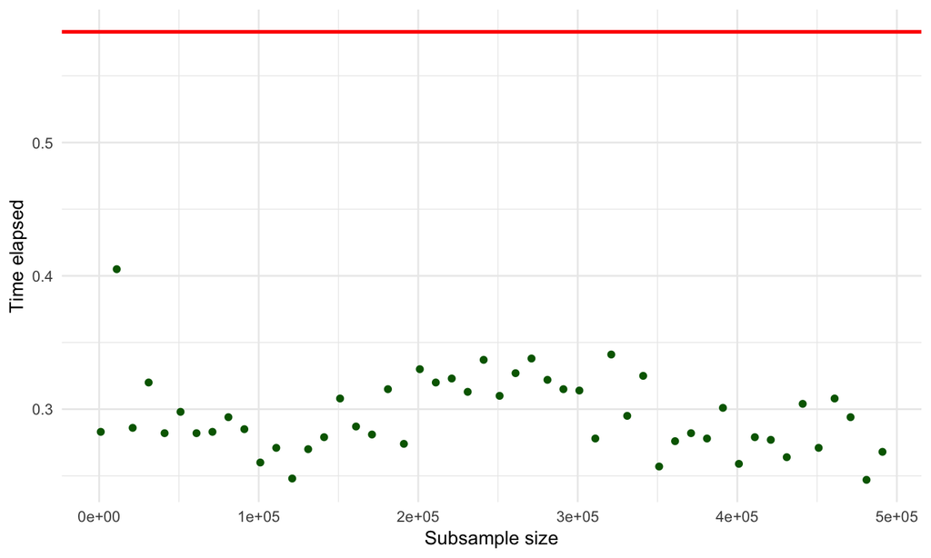

```r
ggplot(plotdata, aes(x = subs_size, y = time_elapsed)) +
     geom_point(color="darkgreen") +
     geom_hline(yintercept = ols_time[3],
                color = "red",
                size = 1) +
     theme_minimal() +
     ylab("Time elapsed") +
     xlab("Subsample size")
```

## Uluru algorithm: Monte Carlo study

1. Precision

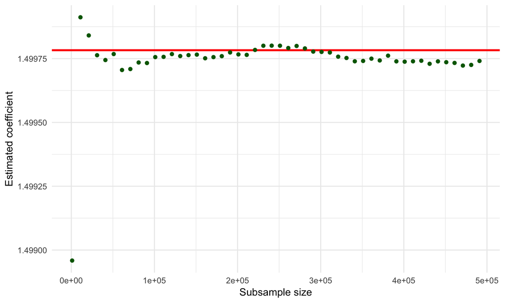

```r
ggplot(plotdata, aes(x = subs_size, y = beta1)) +
     geom_hline(yintercept = ols_res,
                color = "red",
                size = 1) +
     geom_point(color="darkgreen") +

     theme_minimal() +
     ylab("Estimated coefficient") +
     xlab("Subsample size")
```

```r
warnings()
```

## References

Dhillon, Paramveer, Yichao Lu, Dean P. Foster, and Lyle Ungar. 2013. “New Subsampling Algorithms for Fast Least Squares Regression.” In *Advances in Neural Information Processing Systems 26*, 360–68.

Karami, Amir, Aryya Gangopadhyay, Bin Zhou, and Hadi Kharrazi. 2017. “Fuzzy Approach Topic Discovery in Health and Medical Corpora.” *International Journal of Fuzzy Systems* 20 (4): 1334–45.

Murrell, Paul. 2009. *Introduction to Data Technologies*. London, UK: CRC Press.